# Meta-Analysis: Soybean Transpiration Response to VPD

Generated 2026-05-28 15:32 | Project: Limited Transpiration (LT) Trait — Agricultural Water Management manuscript

**Purpose:** This report synthesises published quantitative data on transpiration rate (TR) vs vapor pressure deficit (VPD) in soybean and benchmarks our three growth chamber (GC1–GC3) experiments against the published landscape. Curve parameters are extracted directly from regression tables and figure descriptions in the peer-reviewed literature; our GC data use Day 2 observations (TranspLeafArea, mg m⁻² s⁻¹) normalised to TR at 2.0 kPa for direct cross-study comparison.

## 1. Data Sources and Methods

**Literature studies included (with quantitative TR/VPD parameters):**

- **Fletcher et al. 2007** — *Environ. Exp. Bot.* 61:145-151. Whole-plant gravimetric measurements; greenhouse FL; ~35°C; VPD 1.1–3.7 kPa. 4 genotypes: PI416937, A5959, Graham, PI471938.
- **Sadok & Sinclair 2009a** — *Crop Sci.* 49:955-960. Whole-plant; greenhouse FL; ~32°C; VPD 0.7–3.5 kPa. 7 genotypes including lines with and without PI416937 parentage.
- **Gilbert et al. 2011** — *Field Crops Res.* 124:85-92. Greenhouse NC; Table 1 provides complete TR equations for 10 genotypes (7 LT-class, 3 non-LT). VPD range up to ~4 kPa.
- **Seversike et al. 2013** — *Physiol. Plant.* 148:62-73. Walk-in growth chambers NC; 25 or 30°C growth temperature; VPD 0.5–3.7 kPa. Estimated parameters from text descriptions (PI416937, Hutcheson, 4 *G. soja*).
- **Devi et al. 2014** — *Agron. J.* 106:1947-1954. 9 of 10 elite lines expressed LT trait with BP ≤ 1.9 kPa (breakpoint values only; no full equations published).

**Studies reporting TR/VPD breakpoints but insufficient for curve reconstruction:**

- Sinclair & Ludlow 1986; Sinclair et al. 2008 (Physiol Plant); Sadok & Sinclair 2009b (JXB); Sadok & Sinclair 2010 (Crop Sci — aquaporin inhibitor study, not VPD response curves); Sarkar et al. 2022 (FPLS — RIL population, 32/37°C); Bunce 1984 (only 2 VPD points).

**Our data:** GC1–GC3 (2024–2025); 12 accessions from Chamarthi et al. (2022) WUE plasticity quadrants Q1–Q4; TranspLeafArea (mg H₂O m⁻² s⁻¹) on Day 2.

| type study | Gsoja | LT | Non-LT |
| --- | --- | --- | --- |
| Fletcher 2007 | 0 | 1 | 3 |
| Gilbert 2011 | 0 | 7 | 3 |
| Sadok & Sinclair 2009 | 0 | 2 | 5 |
| Seversike 2013 | 1 | 1 | 1 |

## 2. Absolute Transpiration Rate Curves

Transpiration rate (TR, mg H₂O m⁻² s⁻¹) curves reconstructed from the piecewise-linear regression equations reported in Fletcher 2007, Sadok & Sinclair 2009, and Gilbert 2011. Solid lines = LT genotypes (plateau response above breakpoint); dashed lines = non-LT genotypes (linear increase throughout). The vertical dotted line at 2.0 kPa marks the canonical VPD breakpoint reference.

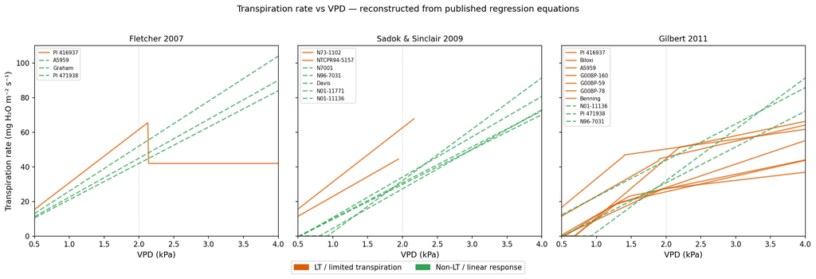

Fig. 1 — Absolute TR vs VPD curves reconstructed from published regression equations. Orange/solid: LT genotypes; green/dashed: non-LT genotypes. Vertical dotted line = 2.0 kPa VPD reference.

## 3. Normalized Curves and Experimental Benchmark

All curves are normalised to TR at 2.0 kPa (the canonical VPD breakpoint) to allow cross-study comparison irrespective of absolute transpiration capacity. Literature curves are shown semi-transparently in the background; GC experimental data (Day 2 means ± SE) are plotted as solid points. The left panel groups LT-class genotypes (PI416937 and PI416937-derived lines, plus our GC Q1 accessions); the right panel groups non-LT genotypes.

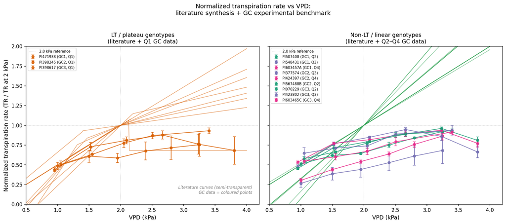

Fig. 2 — Normalized transpiration rate vs VPD. Background semi-transparent lines = literature curves; coloured points = GC1–GC3 experimental data by quadrant.

## 4. VPD Breakpoint Distribution

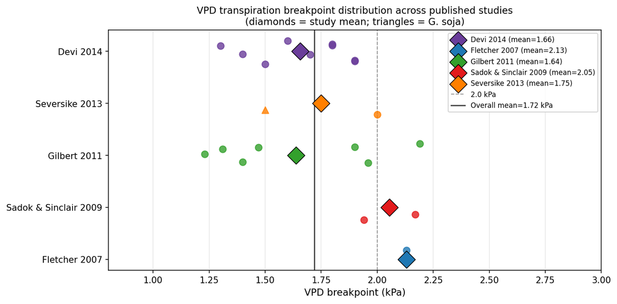

Fig. 3 — Distribution of VPD transpiration breakpoints across studies. Diamonds = study means. Triangles = G. soja. Dashed line = 2.0 kPa canonical reference.

**Key finding:** The VPD breakpoint in soybean LT genotypes is highly reproducible across laboratories, species, and environments. Based on 20 observations spanning 5 studies (2007–2014), the overall mean BP is **1.73 ± 0.30 kPa (SD)** with a range of 1.23–2.19 kPa. *G. soja* accessions tend to express lower BPs (~1.5 kPa) relative to *G. max* LT lines (~2.0 kPa), but lose TR control at temperatures exceeding their growth optimum (Seversike et al. 2013).

## 5. Slope Analysis

The physiological significance of the LT breakpoint is quantified by the dramatic reduction in transpiration sensitivity to VPD above the BP. The left panel compares initial TR slopes (mg H₂O m⁻² s⁻¹ per kPa increase in VPD) in LT vs non-LT genotypes at low VPD; the right panel shows the slope reduction in LT genotypes above the BP.

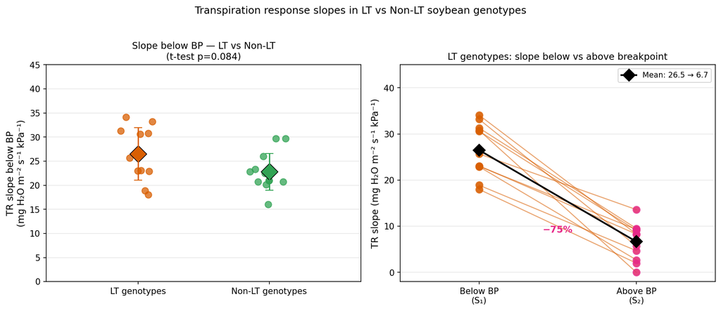

Fig. 4 — Left: TR slope below BP for LT (n=11) vs Non-LT (n=12) genotypes (diamonds = means ± SD). Right: TR slope in LT genotypes below vs above breakpoint (lines connect individual genotypes; black diamond = mean).

| Parameter | n | Mean | SD | Min | Max |
| --- | --- | --- | --- | --- | --- |
| Breakpoint (kPa) — LT genotypes | 20 | 1.73 | 0.30 | 1.23 | 2.19 |
| Slope below BP (mg m⁻² s⁻¹ kPa⁻¹) — LT | 11 | 26.51 | 5.46 | 18.00 | 34.10 |
| Slope above BP (mg m⁻² s⁻¹ kPa⁻¹) — LT | 11 | 6.66 | 3.83 | 0.00 | 13.60 |
| Slope reduction above BP (%) | 11 | 74.90 | NaN | NaN | NaN |
| Overall slope (mg m⁻² s⁻¹ kPa⁻¹) — Non-LT | 12 | 22.81 | 3.81 | 16.00 | 29.73 |

Table 1 — Summary statistics for key transpiration parameters across all literature observations. BP = vapor pressure deficit breakpoint; S₁ = slope below BP; S₂ = slope above BP.

## 6. GC Experimental Benchmark by WUE Quadrant

Each panel shows one of the four Chamarthi et al. (2022) WUE plasticity quadrants. Coloured symbols with error bars show mean ± SE normalized TR from GC1 (blue), GC2 (orange), and GC3 (red) experiments. Background semi-transparent curves show the expected literature shape for each class.

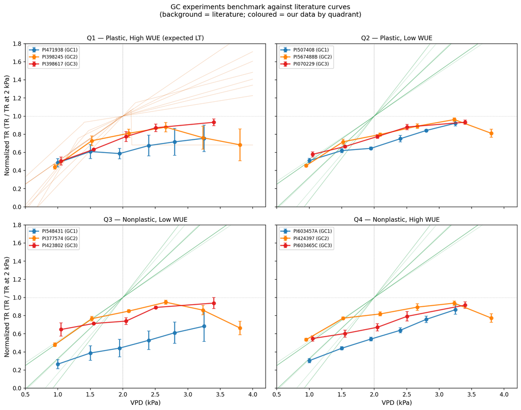

Fig. 5 — GC experimental data (Day 2, normalized to TR at 2.0 kPa) vs literature curves by WUE quadrant. Error bars = SE. Background curves = literature consensus for that TR class.

## 7. Synthesis Consensus

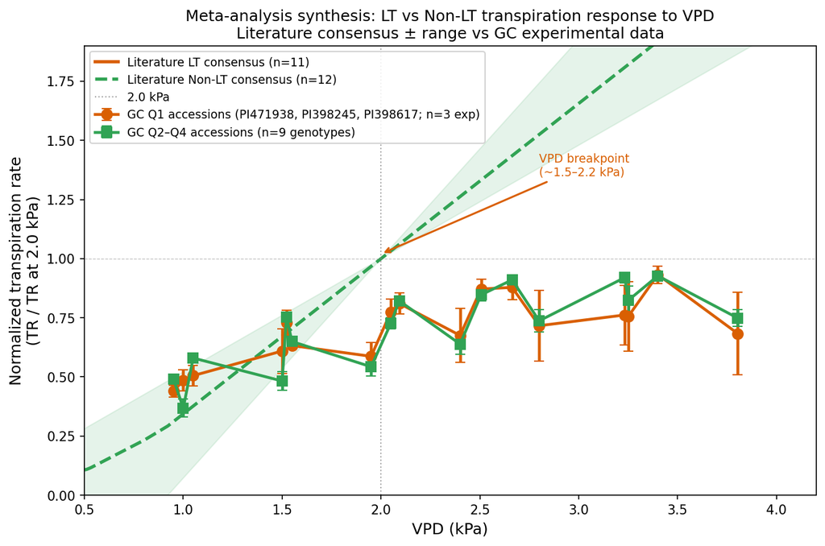

## 8. Detailed Literature Parameter Table

Complete extraction of published TR regression parameters. BP = breakpoint (kPa); S₁ = slope below BP or overall slope (mg H₂O m⁻² s⁻¹ kPa⁻¹); S₂ = slope above BP (— = not applicable for linear genotypes).

| Study | Year | Genotype | Type | BP (kPa) | S₁ | S₂ |
| --- | --- | --- | --- | --- | --- | --- |
| Fletcher 2007 | 2007 | PI 416937 | LT | 2.13 | 30.80 | 0.00 |
| Fletcher 2007 | 2007 | A5959 | Non-LT | NaN | 26.00 | NaN |
| Fletcher 2007 | 2007 | Graham | Non-LT | NaN | 22.50 | NaN |
| Fletcher 2007 | 2007 | PI 471938 | Non-LT | NaN | 21.00 | NaN |
| Sadok & Sinclair 2009 | 2009 | N73-1102 | LT | 1.94 | 22.92 | 2.70 |
| Sadok & Sinclair 2009 | 2009 | NTCPR94-5157 | LT | 2.17 | 31.31 | 9.51 |
| Sadok & Sinclair 2009 | 2009 | N7001 | Non-LT | NaN | 20.17 | NaN |
| Sadok & Sinclair 2009 | 2009 | N96-7031 | Non-LT | NaN | 20.74 | NaN |
| Sadok & Sinclair 2009 | 2009 | Davis | Non-LT | NaN | 22.84 | NaN |
| Sadok & Sinclair 2009 | 2009 | N01-11771 | Non-LT | NaN | 23.30 | NaN |
| Sadok & Sinclair 2009 | 2009 | N01-11136 | Non-LT | NaN | 29.73 | NaN |
| Gilbert 2011 | 2011 | PI 416937 | LT | 2.19 | 34.10 | 8.30 |
| Gilbert 2011 | 2011 | Biloxi | LT | 1.90 | 23.00 | 9.30 |
| Gilbert 2011 | 2011 | A5959 | LT | 1.40 | 33.20 | 5.70 |
| Gilbert 2011 | 2011 | G00BP-160 | LT | 1.23 | 25.70 | 13.60 |
| Gilbert 2011 | 2011 | G00BP-59 | LT | 1.47 | 23.10 | 8.30 |
| Gilbert 2011 | 2011 | G00BP-78 | LT | 1.31 | 30.60 | 9.10 |
| Gilbert 2011 | 2011 | Benning | LT | 1.96 | 18.90 | 4.70 |
| Gilbert 2011 | 2011 | N01-11136 | Non-LT | NaN | 29.70 | NaN |
| Gilbert 2011 | 2011 | PI 471938 | Non-LT | NaN | 21.00 | NaN |
| Gilbert 2011 | 2011 | N96-7031 | Non-LT | NaN | 20.70 | NaN |
| Seversike 2013 | 2013 | PI 416937 (30°C) | LT | 2.00 | 18.00 | 2.00 |
| Seversike 2013 | 2013 | Hutcheson | Non-LT | NaN | 16.00 | NaN |
| Seversike 2013 | 2013 | G. soja (25°C avg) | Gsoja | 1.50 | 15.00 | 2.00 |

## 9. Discussion and Implications

### 9.3 Temperature sensitivity

Seversike et al. (2013) demonstrated that TR control in PI 416937 is maintained up to 35°C but is lost in most other LT genotypes above 30°C. This is agronomically relevant for the US Mid-South (AR, MO, NE), where midday temperatures during reproductive stages regularly exceed 32°C. Simulation outputs from our updated SSM (10 locations, 1990–2019) capture this implicitly through the VPD-dependent breakpoint in the SSM parameterisation.

### 9.5 Connection to Marin-style Kc reduction

Our SSM daily output analysis (modeling_data/scripts/Fig_marin_daily_ETc_ETo.py) demonstrates that the LT trait generates a genotype-specific crop coefficient (Kc) that decreases with increasing daily ETo — precisely the Marin et al. (2016, 2019) empirical finding. The meta-analysis here provides the physiological foundation: the VPD breakpoint (~2.0 kPa) is the mechanism by which stomatal conductance and ETc decouple from ETo at high atmospheric demand, producing the negative slope in the Kc vs ETo relationship documented by Marin. LT2 and LT2.5 genotypes show the strongest Kc reduction at high ETo in the SSM data, consistent with their more restrictive BP parameterisation.

## 10. References

1. Bunce, J.A. (1984). Identifying soybean lines differing in gas exchange sensitivity to humidity. *Ann. Appl. Biol.* 105:313–318.
2. Chamarthi, S.K. et al. (2022). Genome-wide association analysis and genomic prediction for water use efficiency in soybean. *Plant Genome* e20228.
3. Devi, J.M., Sinclair, T.R., Chen, P. & Carter, T.E. (2014). Evaluation of elite southern maturity soybean breeding lines for drought-tolerant traits. *Agron. J.* 106:1947–1954.
4. Fletcher, A.L., Sinclair, T.R. & Allen, L.H. Jr. (2007). Transpiration responses to vapor pressure deficit in well watered 'slow-wilting' and commercial soybean. *Environ. Exp. Bot.* 61:145–151.
5. Gilbert, M.E. et al. (2011). Field confirmation of genetic variation in soybean transpiration response to vapor pressure deficit and photosynthetic compensation. *Field Crops Res.* 124:85–92.
6. Marin, F.R. et al. (2016). Crop coefficient changes with reference evapotranspiration for highly canopy-atmosphere coupled crops. *Agric. Water Manage.* 163:139–145.
7. Marin, F.R. et al. (2019). Evapotranspiration over sugarcane and soybean grown under different VPD conditions. *Theor. Appl. Climatol.* 138:1569–1578.
8. Sadok, W. & Sinclair, T.R. (2009a). Genetic variability of transpiration response to VPD among soybean cultivars. *Crop Sci.* 49:955–960.
9. Sadok, W. & Sinclair, T.R. (2009b). Transpiration response of 'slow-wilting' and commercial soybean genotypes to aquaporin inhibitors. *J. Exp. Bot.* 61:821–829.
10. Sadok, W. & Sinclair, T.R. (2010). Genetic variability of transpiration response of soybean shoots to AgNO₃. *Crop Sci.* 50:1423–1430.
11. Sarkar, S. et al. (2022). Phenotyping and QTL analysis for the limited transpiration trait in a soybean RIL population. *Front. Plant Sci.* 12:779834.
12. Seversike, T.M. et al. (2013). Temperature interactions with transpiration response to VPD among cultivated and wild soybean genotypes. *Physiol. Plant.* 148:62–73.
13. Sinclair, T.R., Zwieniecki, M.A. & Holbrook, N.M. (2008). Low leaf hydraulic conductance associated with drought tolerance in soybean. *Physiol. Plant.* 132:446–451.

Generated by meta_analysis/build_meta_analysis.py | LT-trait repository | Elvis F. Elli, University of Arkansas